# Using R in Power BI

Sudarshana A

August 11, 2020

## Prerequisite

### R Installation

- R must be installed on the same Windows computer as Power BI Desktop

https://www.r-project.org/

Australia - mirrors

| https://cran.csiro.au/ | CSIRO |
| --- | --- |
| https://mirror.aarnet.edu.au/pub/CRAN/ | AARNET |
| https://cran.ms.unimelb.edu.au/ | School of Mathematics and Statistics, University of Melbourne |
| https://cran.curtin.edu.au/ | Curtin University |

### R IDE

- Good to have

IDE to use with R, Notepad++, R Studio, VS etc.

### Power BI Options

We can verify correct R installation and detected IDEs by opening *Options* dialog box. Also using this we can provide a specific R installation and R IDE to use with Power BI.

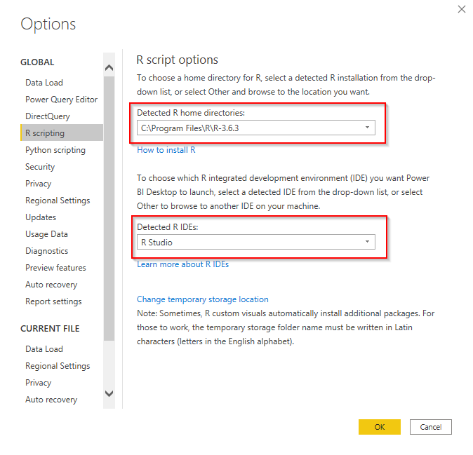

## Import Data

To import data you need to create a dataframe. Power BI can access the dataframes and you can select required dataframes to import.

- Connect to available dataset in R
- import csv, xlsx, sql etc. data to R then connect
- import data to R, transform, clean up data and then connect

### Example 1 - Connect to available dataset in R

We can use available dataset in R and import this to Power BI

`cars` dataset in R consist of breaking distances vs. speed data.

we can preview the data using `head()` function.

```r
head(cars)
```

```
##   speed dist
## 1     4    2
## 2     4   10
## 3     7    4
## 4     7   22
## 5     8   16
## 6     9   10
```

Lets import this dataset to Power BI by assigning to a dataframe.

In **Power BI**, click *Get Data -> Other -> R script*

[figure not shown]

Click Connect

Use the following R script to get the data from *cars* dataset.

```r
cars_data <- cars
```

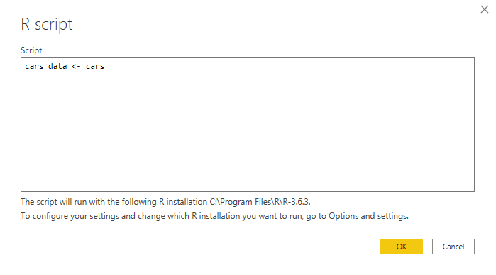

Click OK

We can select required dataframe to Load/Tranform in Power BI

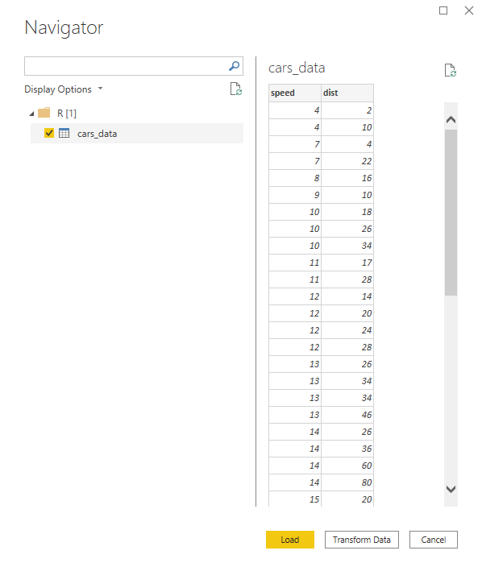

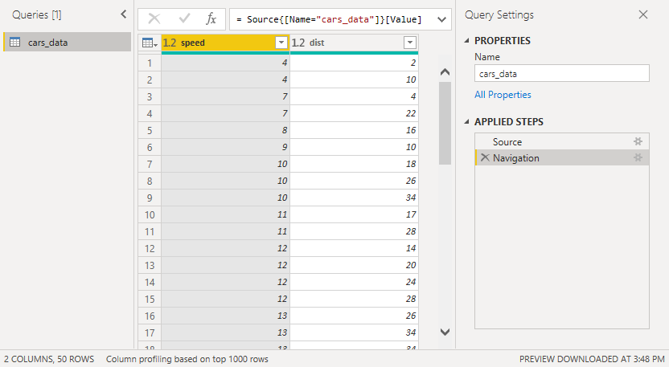

### Example 2 - import csv, xlsx, sql etc. to R / transform

```r
library(readxl)

CompletedWORwA <- read_excel("C:/<directory path>/CompletedWORwA.xlsx")

HFC_NSW <- subset(CompletedWORwA, TECHNOLOGY =='HFC' & STATE == 'NSW')
```

Power BI Navigator

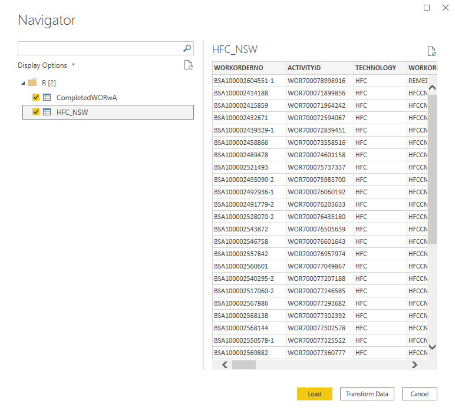

## Tranform Data

We can transform Power BI data using R scripts. Power BI Query Editor can apply R Scripts to a dataset in order to transform the data.

[figure not shown]

```r
library(dplyr)

output <- summarise(group_by(dataset,TECHCODE), freq = n())
```

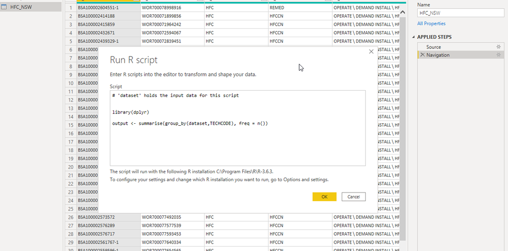

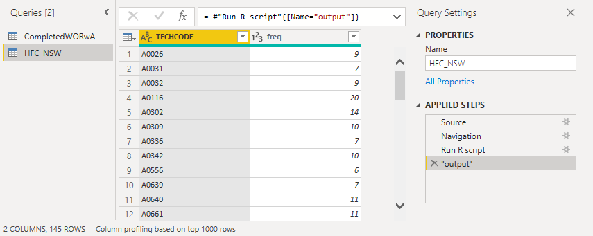

## Visualisations

Use R button on the Visualizations pane, this adds a graphic placeholder to the report and opens the R script editor pane.

We need to select required columns from the Fields pane, or drag columns to Values section of the Visulisations pane in Power BI.

[figure not shown]

Select `dist` and `speed` from the cars dataset and use below script to show scatter plot of dist vs speed.

[figure not shown]

```r
# The following code to create a dataframe and remove duplicated rows is always executed and acts as a preamble for your script:

# dataset <- data.frame(dist, speed)
# dataset <- unique(dataset)

# Paste or type your script code here:
plot(dataset$speed, dataset$dist)
```